# The RateBeer Case: Instructor Solution

MKT 566 · Fall 2026

## Task 1: look at the data

```r
head(beer)
```

```
##                                             beer_name beer_beerId beer_brewerId
##                                                <char>      <char>         <int>
## 1:                 John Harvards Fancy Lawnmower Beer       64125          8481
## 2: Barley Island Dirty &quot;Old&quot; Helen Sour Ale      114513          3228
## 3:  Barley Island Sinister Minister Belgian Black Ale       77833          3228
## 4:  Barley Island Sinister Minister Belgian Black Ale       77833          3228
## 5:  Barley Island Sinister Minister Belgian Black Ale       77833          3228
## 6:  Barley Island Sinister Minister Belgian Black Ale       77833          3228
##    beer_ABV        beer_style review_appearance review_aroma review_palate
##      <char>            <char>            <char>       <char>        <char>
## 1:      5.4             Klsch               2/5         4/10           2/5
## 2:        - Sour Ale/Wild Ale               4/5         8/10           4/5
## 3:      6.7   Traditional Ale               3/5         6/10           3/5
## 4:      6.7   Traditional Ale               4/5         6/10           4/5
## 5:      6.7   Traditional Ale               3/5         6/10           3/5
## 6:      6.7   Traditional Ale               3/5         5/10           3/5
##    review_taste review_overall review_time review_profileName
##          <char>         <char>       <int>             <char>
## 1:         4/10           8/20  1157587200             hopdog
## 2:         8/10          17/20  1266019200              MI2CA
## 3:         6/10          16/20  1237420800            emacgee
## 4:         6/10          14/20  1229040000         after4ever
## 5:         6/10          12/20  1222041600             Sparky
## 6:         6/10          13/20  1221264000            jsquire
```

```r
nrow(beer); ncol(beer)
```

```
## [1] 292680
```

```
## [1] 12
```

```r
str(beer)
```

```
## Classes 'data.table' and 'data.frame':   292680 obs. of  12 variables:
##  $ beer_name         : chr  "John Harvards Fancy Lawnmower Beer" "Barley Island Dirty &quot;Old&quot; Helen Sour Ale" "Barley Island Sinister Minister Belgian Black Ale" "Barley Island Sinister Minister Belgian Black Ale" ...
##  $ beer_beerId       : chr  "64125" "114513" "77833" "77833" ...
##  $ beer_brewerId     : int  8481 3228 3228 3228 3228 3228 3228 3228 3228 3228 ...
##  $ beer_ABV          : chr  "5.4" "-" "6.7" "6.7" ...
##  $ beer_style        : chr  "Klsch" "Sour Ale/Wild Ale" "Traditional Ale" "Traditional Ale" ...
##  $ review_appearance : chr  "2/5" "4/5" "3/5" "4/5" ...
##  $ review_aroma      : chr  "4/10" "8/10" "6/10" "6/10" ...
##  $ review_palate     : chr  "2/5" "4/5" "3/5" "4/5" ...
##  $ review_taste      : chr  "4/10" "8/10" "6/10" "6/10" ...
##  $ review_overall    : chr  "8/20" "17/20" "16/20" "14/20" ...
##  $ review_time       : int  1157587200 1266019200 1237420800 1229040000 1222041600 1221264000 1218240000 1217894400 1212796800 1212537600 ...
##  $ review_profileName: chr  "hopdog" "MI2CA" "emacgee" "after4ever" ...
##  - attr(*, ".internal.selfref")=<pointer: 0x1040242a0>
```

```r
uniqueN(beer$beer_beerId); uniqueN(beer$beer_brewerId); uniqueN(beer$review_profileName)
```

```
## [1] 50826
```

```
## [1] 5841
```

```
## [1] 13030
```

**My prediction:** one row is one review.

**My answer:** 292,680 rows and 12 columns. One row is one **review** of one beer by one reviewer, not one beer: there are 50,826 distinct beers, 5,841 breweries, and 13,030 reviewers. So “reviews by style” counts a beer once per review; a style with a few heavily reviewed beers can look bigger than a style with many lightly reviewed ones.

**Explain it back:** `fread()` (from data.table) reads a CSV like `read.csv()` but is many times faster on large files, and returns a data.table.

## Task 2: find the dirt

```r
for (col in c("beer_ABV", "review_overall", "review_time", "beer_style")) {
  cat("\n==", col, "(", class(beer[[col]]), ")\n")
  print(head(sort(table(beer[[col]]), decreasing = TRUE), 6))
}
```

```
##
## == beer_ABV ( character )
##
##     5     -   5.5     6     8     7
## 25193 14140 11566 11129 10630  9915
##
## == review_overall ( character )
##
## 14/20 15/20 13/20 16/20 12/20 17/20
## 43254 41840 35988 33424 30224 21794
##
## == review_time ( integer )
##
## 1188604800 1227139200 1296950400 1322265600 1299369600 1258156800
##        540        256        213        208        205        200
##
## == beer_style ( character )
##
## India Pale Ale &#40;IPA&#41;                   Pale Lager
##                        18635                        14754
##           Belgian Strong Ale               Imperial Stout
##                        12426                        12157
##          Imperial/Double IPA            American Pale Ale
##                        10559                        10400
```

```r
sort(unique(beer$beer_style))
```

```
##  [1] "Abbey Dubbel"                    "Abbey Tripel"
##  [3] "Abt/Quadrupel"                   "Altbier"
##  [5] "Amber Ale"                       "American Dark Lager"
##  [7] "American Pale Ale"               "American Strong Ale"
##  [9] "Baltic Porter"                   "Barley Wine"
## [11] "Belgian Ale"                     "Belgian Strong Ale"
## [13] "Belgian White &#40;Witbier&#41;" "Berliner Weisse"
## [15] "Bire de Garde"                   "Bitter"
## [17] "Black IPA"                       "Bohemian Pilsener"
## [19] "Brown Ale"                       "California Common"
## [21] "Cider"                           "Classic German Pilsener"
## [23] "Cream Ale"                       "Doppelbock"
## [25] "Dortmunder/Helles"               "Dry Stout"
## [27] "Dunkel"                          "Dunkelweizen"
## [29] "Dunkler Bock"                    "Eisbock"
```

[output cut: 30 more lines]

**My answer:**

- The five `review_` columns are **text** like `"14/20"`: the score and its scale glued together. R cannot average text.
- `beer_ABV` is text too, because 14,140 rows contain `"-"`. It means **missing**, not zero: real non-alcoholic beers appear in the data with ABV 0.0–0.5, and treating 14,140 missing values as zero would pull the mean ABV from 6.6 down to about 6.3 and put 14,000 beers in the “alcohol-free” bin.
- `review_time` is a **Unix timestamp**: seconds since January 1, 1970. 1157587200 is September 7, 2006.
- `beer_style` includes sake (12 styles starting with `Sak`), cider, perry, and mead. Several names are garbled by encoding: `Klsch` (Kölsch), `Oktoberfest/Mrzen` (Märzen), `Bire de Garde`, and HTML entities such as `&#40;IPA&#41;` for “(IPA)”. Cosmetic, but a reminder that the data went through a scraper.

**Explain it back:** a number column stores quantities R can add and average; a text column stores characters. `"14/20"` is a string of five characters, so `mean()` has nothing to compute until we extract the 14.

## Task 3: clean it

```r
rating_cols <- c("review_overall", "review_aroma", "review_appearance",
                 "review_palate", "review_taste")
for (col in rating_cols) beer[, (col) := as.numeric(sub("/.*", "", get(col)))]
beer[, beer_ABV := as.numeric(ifelse(beer_ABV == "-", NA, beer_ABV))]
beer[, review_date := as.Date(as.POSIXct(review_time, origin = "1970-01-01", tz = "UTC"))]
n_before <- nrow(beer)
beer <- beer[!grepl("Sak|Cider|Perry|Mead", beer_style)]
n_before - nrow(beer); nrow(beer)
```

```
## [1] 3693
```

```
## [1] 288987
```

```r
summary(beer[, c(rating_cols, "beer_ABV", "review_date"), with = FALSE])
```

```
##  review_overall  review_aroma    review_appearance review_palate
##  Min.   : 1.0   Min.   : 1.000   Min.   :1.000     Min.   :1.000
##  1st Qu.:12.0   1st Qu.: 6.000   1st Qu.:3.000     1st Qu.:3.000
##  Median :14.0   Median : 7.000   Median :3.000     Median :3.000
##  Mean   :13.2   Mean   : 6.355   Mean   :3.436     Mean   :3.258
##  3rd Qu.:15.0   3rd Qu.: 7.000   3rd Qu.:4.000     3rd Qu.:4.000
##  Max.   :20.0   Max.   :10.000   Max.   :5.000     Max.   :5.000
##
##   review_taste       beer_ABV       review_date
##  Min.   : 1.000   Min.   : 0.010   Min.   :2000-04-26
##  1st Qu.: 6.000   1st Qu.: 5.000   1st Qu.:2006-05-18
##  Median : 7.000   Median : 5.900   Median :2008-07-02
##  Mean   : 6.451   Mean   : 6.616   Mean   :2008-03-04
##  3rd Qu.: 8.000   3rd Qu.: 8.000   3rd Qu.:2010-05-06
##  Max.   :10.000   Max.   :57.700   Max.   :2012-01-13
##                   NAs    :14019
```

```r
sum(is.na(beer$beer_ABV))
```

```
## [1] 14019
```

**My answer:** overall is on a 1–20 scale, taste and aroma 1–10, appearance and palate 1–5, so a taste of 7 is 70% of its scale while an overall of 14 is 70% of a different one; they can only be compared after rescaling. Removing non-beers dropped 3,693 rows, leaving 288,987. 14,019 reviews have a missing ABV: keep them for everything about ratings, and drop them only in the ABV charts (that is what `na.rm = TRUE` does). Reviews run from April 2000 to January 13, 2012.

**Explain it back:** `sub("/.*", "", x)` deletes the slash and everything after it, turning `"14/20"` into `"14"`; `as.numeric()` then makes it a number.

## Task 4: variation warm-up

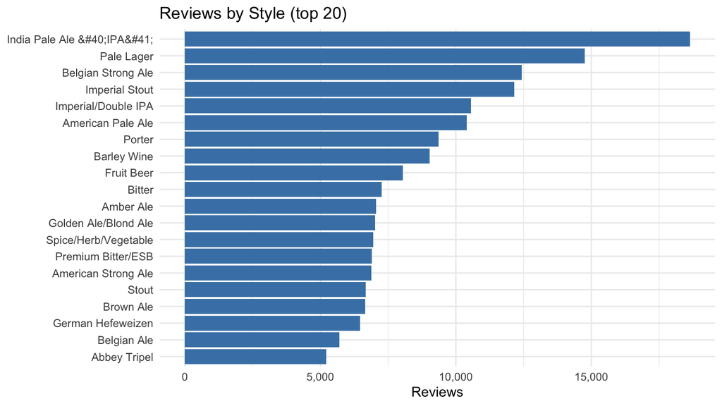

```r
style_n <- beer[, .N, by = beer_style][order(-N)][1:20]
ggplot(style_n, aes(x = reorder(beer_style, N), y = N)) +
  geom_col(fill = "steelblue") +
  coord_flip() +
  scale_y_continuous(labels = comma) +
  labs(title = "Reviews by Style (top 20)", x = NULL, y = "Reviews") +
  theme_minimal()
```

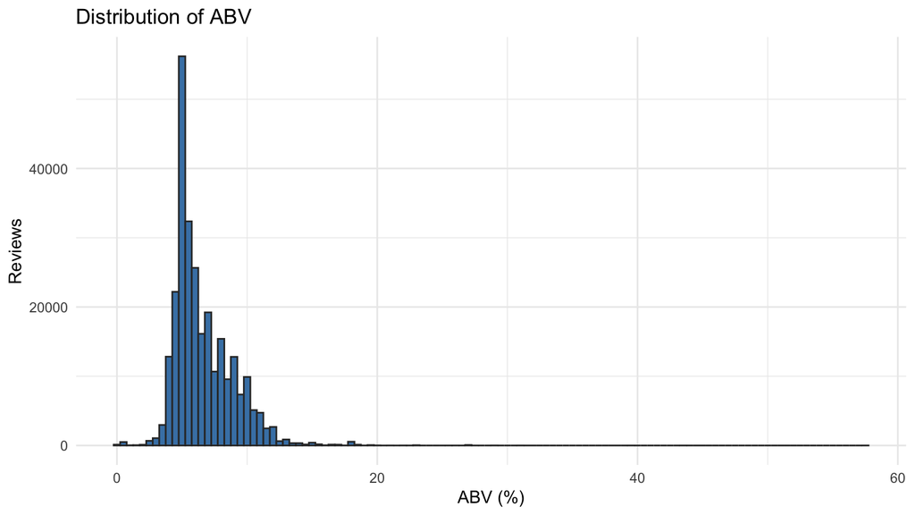

```r
ggplot(beer[!is.na(beer_ABV)], aes(beer_ABV)) +
  geom_histogram(binwidth = 0.5, fill = "steelblue", color = "grey20") +
  labs(title = "Distribution of ABV", x = "ABV (%)", y = "Reviews") +
  theme_minimal()
```

```r
beer[which.max(beer_ABV), .(beer_name, beer_style, beer_ABV)]
```

```
##                                          beer_name beer_style beer_ABV
##                                             <char>     <char>    <num>
## 1: Schorschbru Schorschbock 57% finis coronat opus    Eisbock     57.7
```

**My prediction:** IPA most reviewed; typical ABV around 5–6%.

**My answer:** IPAs lead (18,635 reviews), then Pale Lager, Belgian Strong Ale, and Imperial Stout. “Most reviewed” measures what RateBeer’s users, who are enthusiasts, like to write about: Pale Lager is by far the most *consumed* style in the world and it is second here only because everybody has tried one. For a craft brewery, review volume is a proxy for enthusiast attention, not sales. ABV is right-skewed: most reviews are of beers between 4% and 8%, with a long tail. The maximum, Schorschbräu Schorschbock at 57.7%, is a real product (a freeze-distilled Eisbock that held the world record), not a typo. Outliers are not necessarily errors; check before dropping.

**Explain it back:** `reorder(beer_style, N)` sorts the style labels by their review count, so the bars come out in order instead of alphabetically.

## Task 5: rating by style

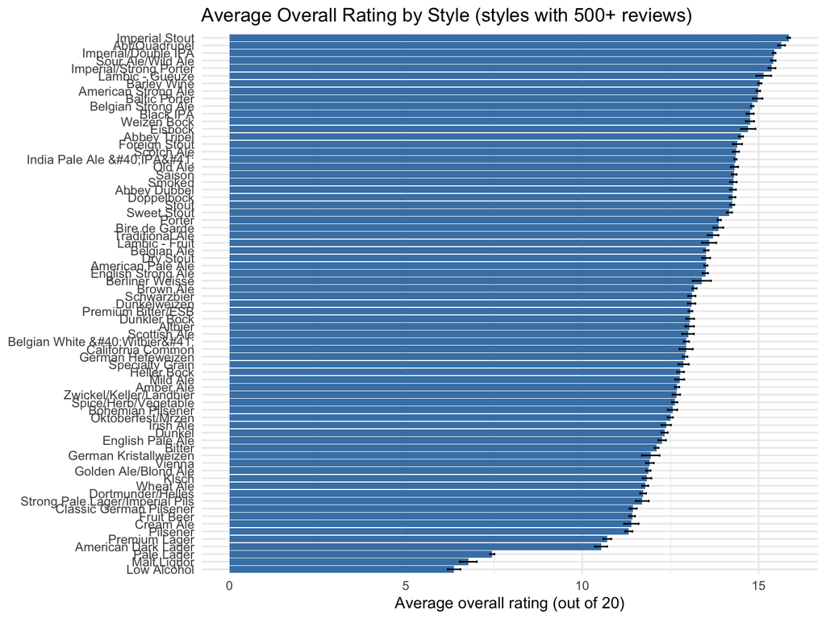

```r
style_stats <- beer[, .(avg = mean(review_overall), se = sd(review_overall) / sqrt(.N),
                        n = .N, abv = mean(beer_ABV, na.rm = TRUE)), by = beer_style][n >= 500]
ggplot(style_stats, aes(x = reorder(beer_style, avg), y = avg)) +
  geom_col(fill = "steelblue") +
  geom_errorbar(aes(ymin = avg - 1.96 * se, ymax = avg + 1.96 * se), width = 0.3) +
  coord_flip() +
  labs(title = "Average Overall Rating by Style (styles with 500+ reviews)",
       x = NULL, y = "Average overall rating (out of 20)") +
  theme_minimal()
```

```r
style_stats[order(-avg)][c(1:3, (.N - 2):.N), .(beer_style, avg = round(avg, 2), n, abv = round(abv, 1))]
```

```
##             beer_style   avg     n   abv
##                 <char> <num> <int> <num>
## 1:      Imperial Stout 15.85 12157  10.2
## 2:       Abt/Quadrupel 15.65  1966  10.4
## 3: Imperial/Double IPA 15.44 10559   9.1
## 4:          Pale Lager  7.45 14754   4.7
## 5:         Malt Liquor  6.77  1489   7.2
## 6:         Low Alcohol  6.37  1264   1.2
```

**My prediction:** IPAs highest, light lagers lowest.

**Explain it back:** the standard error, `sd / sqrt(n)`, says how much the average would move if we drew another sample of reviews; mean ± 1.96 × SE is the range (95% confidence interval) where the true average plausibly sits.

## Task 6: rating vs. alcohol

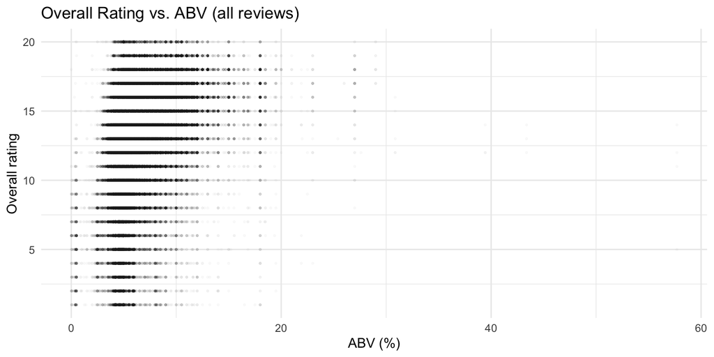

```r
ggplot(beer[!is.na(beer_ABV)], aes(beer_ABV, review_overall)) +
  geom_point(alpha = 0.02, size = 0.5) +
  labs(title = "Overall Rating vs. ABV (all reviews)", x = "ABV (%)", y = "Overall rating") +
  theme_minimal()
```

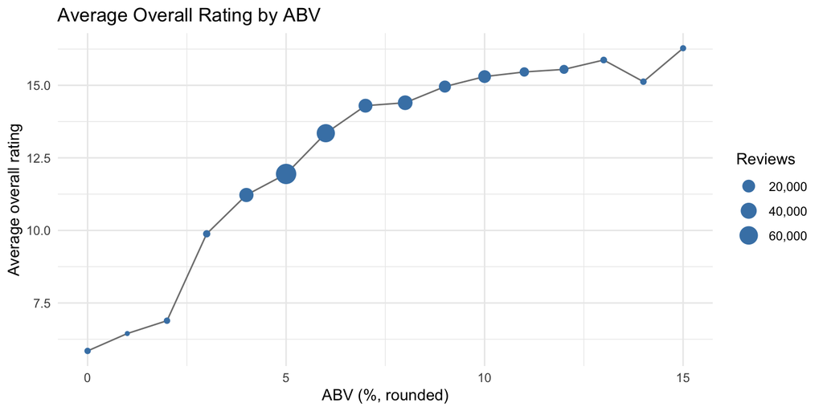

```r
abv_bins <- beer[!is.na(beer_ABV) & beer_ABV <= 15,
                 .(avg = mean(review_overall), n = .N), by = .(abv = round(beer_ABV))]
ggplot(abv_bins, aes(abv, avg)) +
  geom_line(color = "grey50") +
  geom_point(aes(size = n), color = "steelblue") +
  scale_size_continuous(labels = comma) +
  labs(title = "Average Overall Rating by ABV", x = "ABV (%, rounded)",
       y = "Average overall rating", size = "Reviews") +
  theme_minimal()
```

```r
cor(beer$beer_ABV, beer$review_overall, use = "complete.obs")
```

```
## [1] 0.3985461
```

**My prediction:** stronger beers rated higher.

**My answer:** The raw scatter is a blob: 275,000 points on a grid of integer ratings, so nothing is visible even with transparency. Averaging within each ABV value shows a strong positive relationship: from about 11/20 at 3–4% to 15/20 at 9–10%, with a correlation of 0.40. Above 10% the curve flattens; beyond 13% the averages bounce around because few beers exist there. Causal? Not necessarily: strong beers are mostly imperial stouts, quadrupels, and barley wines, brewed with more ingredients and care, and reviewed by enthusiasts who sought them out. A 12% beer is rarely a casual purchase, so its reviews come from people predisposed to like it.

**Explain it back:** `by = .(abv = round(beer_ABV))` groups every review by its ABV rounded to the nearest percent and averages the ratings inside each group, turning 275,000 points into 16, which is why the chart became readable.

## Task 7: the brewery table

```r
brewer <- beer[, .(n_styles = uniqueN(beer_style), n_reviews = .N,
                   avg = mean(review_overall)), by = beer_brewerId][n_reviews >= 10]
nrow(brewer); summary(brewer$n_styles)
```

```
## [1] 2439
```

```
##    Min. 1st Qu.  Median    Mean 3rd Qu.    Max.
##    1.00    5.00    8.00   10.53   13.00   49.00
```

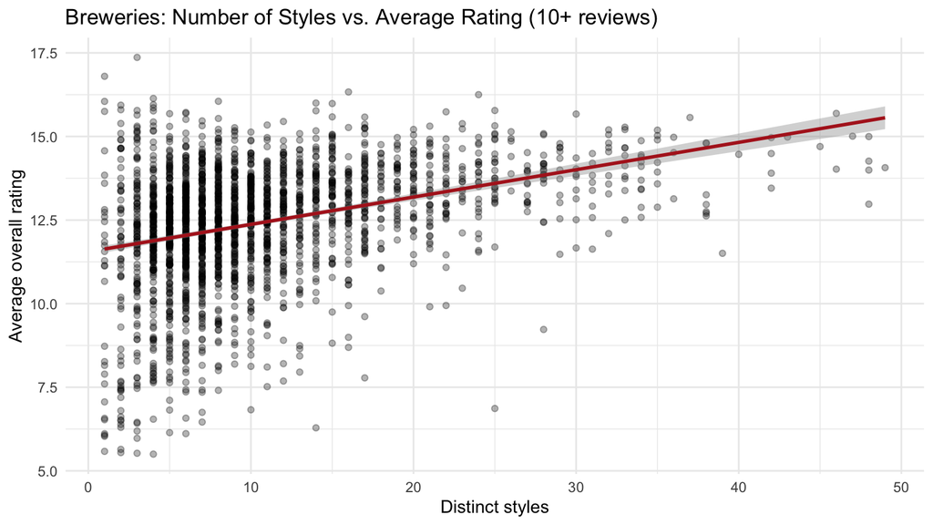

```r
ggplot(brewer, aes(n_styles, avg)) +
  geom_point(alpha = 0.3) +
  geom_smooth(method = "lm", color = "firebrick") +
  labs(title = "Breweries: Number of Styles vs. Average Rating (10+ reviews)",
       x = "Distinct styles", y = "Average overall rating") +
  theme_minimal()
```

```r
cor(brewer$n_styles, brewer$avg)
```

```
## [1] 0.3499834
```

```r
brewer[order(-avg)][1]; brewer[order(avg)][1]
```

```
##    beer_brewerId n_styles n_reviews      avg
##            <int>    <int>     <int>    <num>
## 1:           623        3       422 17.36493
```

```
##    beer_brewerId n_styles n_reviews   avg
##            <int>    <int>     <int> <num>
## 1:          4603        4        48   5.5
```

**My prediction:** more styles, higher rating.

**My answer:** 2,439 breweries with at least 10 reviews; the median brewery has 8 styles, a quarter have 13 or more. Breadth and rating are positively related (correlation 0.35): breweries with 20+ styles average about 13.7 versus 10.6 for single-style breweries. Two stories other than “variety makes you good”: survivorship (only breweries that were already good and popular lasted long enough to launch many styles), and reverse causality (good ratings bring demand, and demand funds new styles). Highest-rated brewery with 10+ reviews: id 623 (17.4 on 422 reviews); lowest: id 4603 (5.5 on 48).

**Explain it back:** `by = beer_brewerId` collapses the 289,000 review rows into one row per brewery, computing the three summaries inside each group; the individual reviews are gone from this table, only their summaries remain.

## Task 8: over time

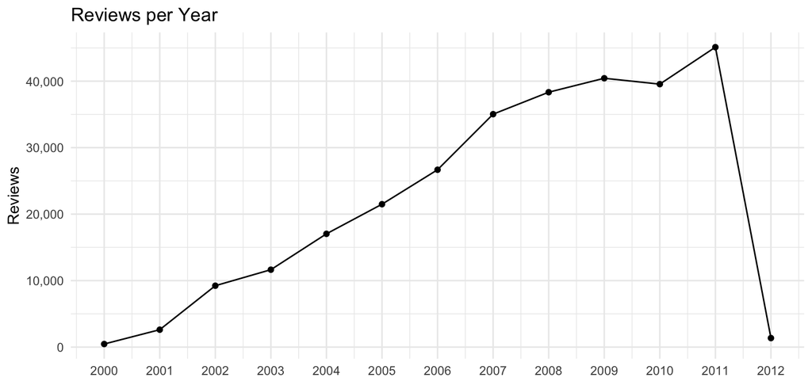

```r
by_year <- beer[, .(reviews = .N, avg = mean(review_overall)), by = .(year = year(review_date))][order(year)]
ggplot(by_year, aes(year, reviews)) + geom_line() + geom_point() +
  scale_y_continuous(labels = comma) + scale_x_continuous(breaks = 2000:2012) +
  labs(title = "Reviews per Year", x = NULL, y = "Reviews") + theme_minimal()
```

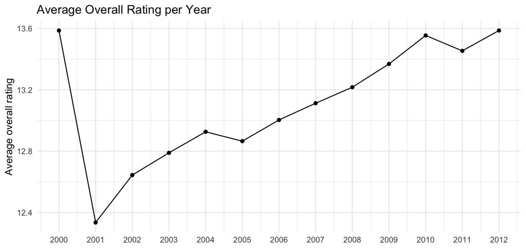

```r
ggplot(by_year, aes(year, avg)) + geom_line() + geom_point() +
  scale_x_continuous(breaks = 2000:2012) +
  labs(title = "Average Overall Rating per Year", x = NULL, y = "Average overall rating") +
  theme_minimal()
```

```r
range(beer$review_date)
```

```
## [1] "2000-04-26" "2012-01-13"
```

**My prediction:** ratings flat.

**My answer:** Reviews grow from 461 in 2000 to 45,112 in 2011, then “collapse” to 1,355 in 2012, because the data ends on January 13, 2012: the last year has 13 days, not a crisis. Reporting a partial period as a drop is the most common trend-chart mistake. The average rating drifts up from 12.3 (2001) to 13.5 (2011). Two non-beer explanations: the reviewer population changed (early users were hardcore critics, later ones more generous), and the mix of beers changed (the craft boom means more imperial stouts and IPAs, which score higher, in the later years).

**Explain it back:** `year(review_date)` extracts the four-digit year from a date, so `by = year` groups all reviews posted in the same calendar year.

## Task 9: the recommendation

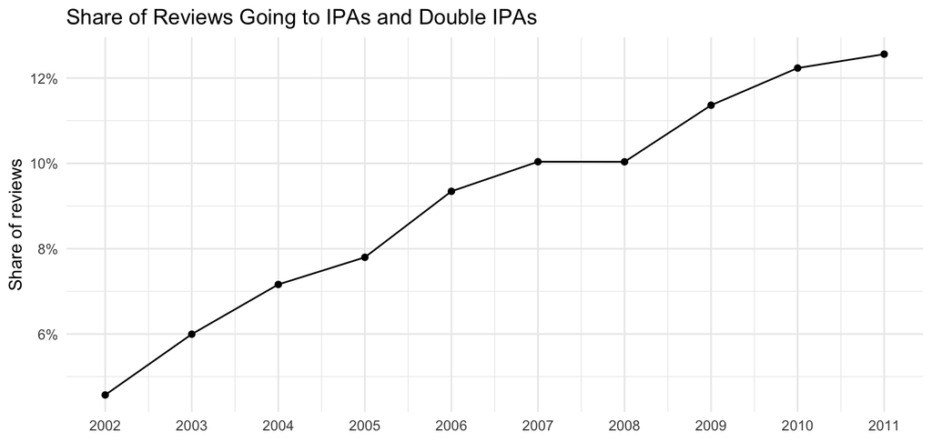

```r
share <- beer[year(review_date) %in% 2002:2011,
              .(share = mean(beer_style %in% c("India Pale Ale &#40;IPA&#41;", "Imperial/Double IPA"))),
              by = .(year = year(review_date))][order(year)]
ggplot(share, aes(year, share)) + geom_line() + geom_point() +
  scale_y_continuous(labels = percent) + scale_x_continuous(breaks = 2002:2011) +
  labs(title = "Share of Reviews Going to IPAs and Double IPAs", x = NULL, y = "Share of reviews") +
  theme_minimal()
```

1. **Lead with a strong, intense style.** Imperial stouts, quadrupels, and double IPAs average 15.4–15.9/20 versus 7.4 for pale lager (Task 5), and ratings rise with ABV up to about 10% (Task 6). A flagship in the 8–10% range plays where enthusiasts are most generous.
2. **Include an IPA and plan to grow the range.** IPAs are the most reviewed style (Task 4) and their share of all reviews grew from under 5% in 2002 to 13% in 2011 (chart above); breweries with broader portfolios are rated higher (Task 7, correlation 0.35), though partly because good breweries survive to grow.
3. **Limitation: this is enthusiast attention, not sales.** RateBeer users under-represent the pale-lager drinker who accounts for most beer volume, and the data has no prices, costs, or volumes. Use it to pick what wins with the enthusiast segment, and validate volume and margin elsewhere.